# fullsibQTL tutorial

Scott Brainard

4/28/2021

## Introduction

`fullsibQTL` is an R package to perform QTL scans and analysis using genetic maps generated from F1 outcross populations using `onemap` (which `fullsibQTL` also depends on). This tutorial demonstrates some of the functionality of fullsibQTL by making use of an F1 apple marker dataset from [Gardner et al., 2014](https://doi.org/10.1534/g3.114.011023). The unfiltered VCF file can be downloaded from DataDryad: http://doi.org/10.5061/dryad.55t54. Here, a filtered and converted version of this VCF file is used at the input file to `onemap`.

This population was derived from a cross between apple varieties with contrasting skin color:

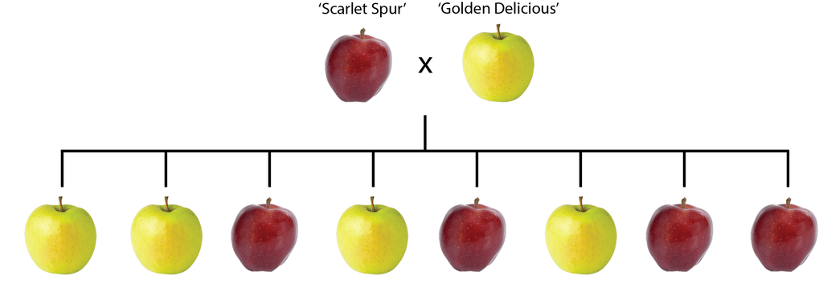

## Review: constructing the genetic map using `onemap`

First, we will generate a genetic map for all 17 chromosomes in apple using `onemap`. Using the method introduced previously, the first step is to form linkage groups:

```r
library(onemap) #version 2.2.0
library(ggplot2)

apple <- read_onemap(dir = "./input_files", inputfile = "apple_onemap_DP4.txt")
apple.bins <- find_bins(apple, exact = FALSE)
apple.binned <- create_data_bins(apple, apple.bins)
plot_by_segreg_type(apple)
apple.segreg_test <- test_segregation(apple.binned)
plot(apple.segreg_test)
apple.no_dist <- select_segreg(apple.segreg_test, distorted = FALSE, numbers = TRUE)
apple.twopts <- rf_2pts(apple.binned, LOD = 4, max.rf = 0.4)
apple.mrks.no_dist <- make_seq(apple.twopts, c(apple.no_dist))
apple.LGs <- group(apple.mrks.no_dist, LOD = 11, max.rf = 0.4 )
```

We can compare these LG against the apple reference using the tabulation method used previously:

```r
chroms <- sapply(strsplit(apple.LGs$marnames,split="-",fixed=T),"[",1)
chr_vs_LG <- data.frame(Marker = apple.LGs$marnames, LG = apple.LGs$groups, Chr = chroms, SeqNum = apple.LGs$seq.num)
selected_LGs <- which(chr_vs_LG$LG %in% c(1:6,8:10,12:14,16:17,19,20,23))
chr_vs_LG <- chr_vs_LG[selected_LGs,]
tab <- table(chr_vs_LG$Chr,chr_vs_LG$LG)
```

By using additional markers in the input file (by decreasing the 90% quantile depth filter), we now have markers on all chromosomes included in our linkage groups, including chromosome 9 (linkage group 20), which is where we expect a single QTL:

```r
tab[,order(apply(tab,2,which.max))]
```

```
##
##       17   1  14  19  23  10   2   6  13  16  12   4   3   8   5   9  20
##   1   75   1   1   1   1   1   8   3   3   2   0   1   2   1   9   0   1
##   10   0 101   0   0   0   1   2   1   2   0   1   2  11   1   5   2   0
##   11   2   1 166   0   0   1   1   0   0   5   3   0   3   1   3   3   0
##   12   2   2   1 107   0   3   2   0   0   0   0   0   0   1   1   4   0
##   13   1   1   1   5 132   5   3  14   0   0   4   0   4   0   0   2  13
##   14   4   5   0   3   0  94   1   0   0   0   3   0   4   4   1   1   1
##   15   3   3   0   0   0   1 149   0   1   4   0   4   9   4   4   2   3
##   16   2   3   0   0   0   0   0  86   4   0   0   2   0   0   0   0   0
##   17   0   0   0   0   0   1   4   1 108   0   0   0   2   0   2   0   5
##   2    3   5   2   0   0   1   4   2   1 126   0   1   1   0   3   3   2
##   3    3   2   2   1   1   0   0   0   2   0 136   3   5   0   0   1   0
##   4    1   1   0   4   2   0   0   3   0   0   1  88   2   0   5   0   1
##   5    0   4   0   0   1   0   2   7   2   4   1   6 111   0   0   0   2
##   6    3   0   0   0   0   0   0   1   0   3   0   1   4  48   0   1   0
##   7    2   0   1   2   2   0   0   1   0   1   0   3   2   0  79   1   0
##   8    2   3   0   6   0   1   6   0   1   1   2   0  14   0   1 102   0
##   9    0   2   0   2   1   0   2   2   1   0   5   5   9   0   1   4 111
```

Now we can construct ordered maps for each of these LGs, and save them as individual .rda files:

```r
set_map_fun(type="kosambi")
for(i in c(1:6,8:10,12:14,16:17,19,20,23)){
  apple.LG <- make_seq(apple.LGs, i)
  apple.LG.ord <- order_seq(apple.LG, n.init=5, touchdown=TRUE)
  apple.LG.final <- make_seq(apple.LG.ord,"force")
  ord.filename <- paste("./orders/LG_", i, ".rda", sep = "")
  save(apple.LG.ord, apple.LG.final, apple.LG_mds, file = ord.filename)

  rf.filename <- paste("./heatmaps/rf_heatmap_LG_", i, ".pdf", sep = "")
  pdf(rf.filename, width = 30, height = 30)
  print(rf_graph_table(apple.LG.final, mrk.axis = "numbers"))
  dev.off()
}
```

Now I will read these back into memory, and write out the final map:

```r
for(i in c(1:6,8:10,12:14,16:17,19,20,23)){
  ord.filename <- paste("./orders/LG_", i, ".rda", sep = "")
  load(ord.filename)
  LG_name <- paste("LG", i, "_final", sep = "")
  assign(LG_name, apple.LG.final)
}

write_map(list( LG1_final, LG2_final, LG3_final, LG4_final,
                LG5_final, LG6_final, LG8_final, LG9_final,
                LG10_final, LG12_final, LG13_final, LG14_final,
                LG16_final, LG17_final, LG19_final, LG20_final,
                LG23_final), "map.txt")

p <- draw_map2(LG1_final, LG2_final, LG3_final, LG4_final, LG5_final,
               LG6_final, LG8_final, LG9_final, LG10_final, LG12_final,
               LG13_final, LG14_final, LG16_final, LG17_final, LG19_final, LG20_final,
               LG23_final, main = "F1 apple map",  group.names = c("LG1", "LG2", "LG3", "LG4", "LG5",
                                                                   "LG6", "LG8", "LG9", "LG10", "LG12",
                                                                   "LG13", "LG14", "LG16", "LG17", "LG19", "LG20",
                                                                   "LG23"))
```

The `map.txt` file contains columns for linkage group, marker name, and cM position:

```r
head(read.table("map.txt"))
```

```
##   V1              V2        V3
## 1  1     10-280310-5  0.000000
## 2  1     10-280258-4  7.132403
## 3  1   10-2063680-12 15.537571
## 4  1   10-1887928-11 20.809478
## 5  1   10-1887205-10 24.296178
## 6  1 10-26811389-157 33.077278
```

And the draw_map2 function produces an `.eps` file with the complete map represented graphically:

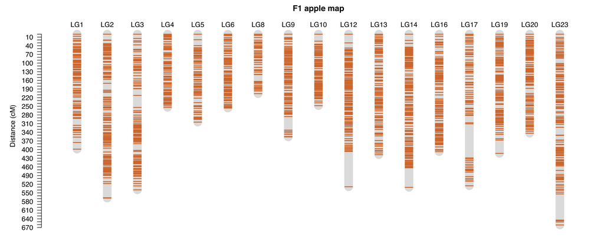

Clearly there is some inflation currently. This is likely both due to local errors in order, as well as a lack of multipoint regression to shrink map distances. The former could be addressed by performing the marker curation steps shown in the earlier `onemap` tutorial, but due to the uninformative nature of the marker used here, this will likely remain a problem. For now, we will proceed with QTL analysis using `fullsibQTL`.

The first step in using `fullsibQTL` is to read in the original input file to one `onemap` (using `read_onemap`), and then create the basic data object used by `fullsibQTL` using the function `create_fullsib`. Here I have added in the trait data to the `onemap` input file, which is a binary score indicating whether the apple had red skin, or green/yellow skin.

## Performing single QTL analysis using `fullsibQTL`

```r
library(fullsibQTL) # version 0.0.9010
ROOT <- "~/Box/Courses/Genetic_Mapping_2021/Lectures/Week7/apple/input_files"
fs_data <- read_onemap(dir = ROOT, inputfile = "apple_onemap_DP4_pheno.txt")
## Information of linkage groups, step and mapping function
fsib <- create_fullsib( fs_data,
                        map.list = list( LG1_final, LG2_final, LG3_final, LG4_final,
                                         LG5_final, LG6_final, LG8_final, LG9_final,
                                         LG10_final, LG12_final, LG13_final, LG14_final,
                                         LG16_final, LG17_final, LG19_final, LG20_final,
                                         LG23_final),
                        step = 1, map.function = "kosambi")
```

Interval mapping can be used to scan for a single QTL using the command `im_scan`. This performs a scan similar to `scanone` in `qtl`, using the EM algorithm to get ML estimates of the mixture model parameters.

```r
im <- im_scan( fullsib = fsib, lg = "all", pheno.col = 1, LOD = TRUE )
```

LOD profiles can then be plotted for the entire genome, or specific LGs:

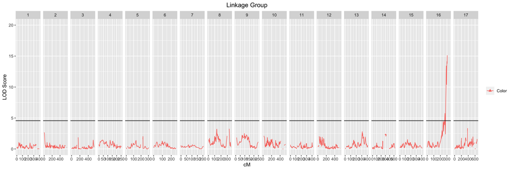

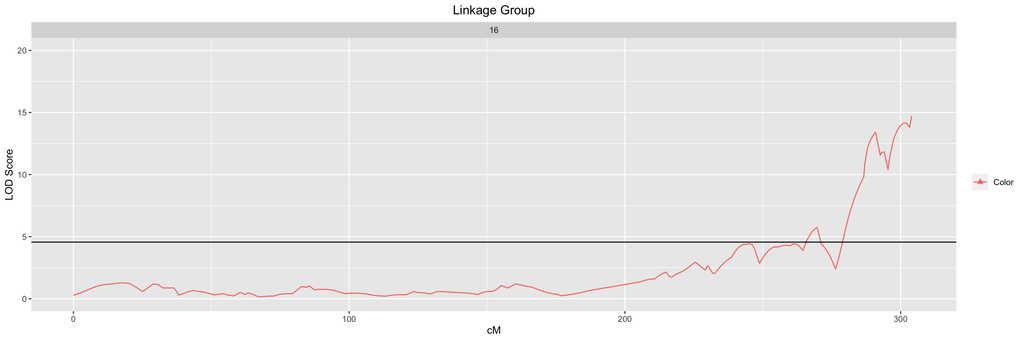

```r
plot_fullsibQTL(fullsib = fsib, im, qtlmapping = "Color") +
  scale_y_continuous(limits = c(0,20)) +
  geom_hline(yintercept = -log10(0.05/1819)) #set the limit to be between 0 and 20

plot_fullsibQTL(fullsib = fsib, fullsib.scan = im, lgs = 16, qtlmapping = "Color") +
  scale_y_continuous(limits = c(0,20)) +
  scale_x_continuous(limits = c(0,305)) +
  geom_hline(yintercept = -log10(0.05/1819))
```

This is very similar to the results published by Gardner et al., using single marker regression in `r/qtl`:

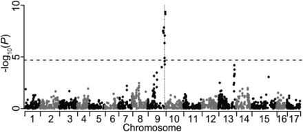

`summary` returns the most significant markers on each LG:

```r
summary(im)
```

[output not shown]

We can then look more closely at specific QTL using `im_char`.

```r
(qtl1 <- im_char(fsib, pheno.col = 1, lg = 16, pos = "9-29305493-3533"))
```

```
9-29305493-3533
LG              1.600000e+01
pos             3.137978e+02
-log10(pval)    2.810093e+01
LOD_Ha          2.903897e+01
mu              3.902439e-01
alpha_p        -4.205854e-03
LOD_H1          7.046611e-03
alpha_q        -4.453872e-01
LOD_H2          2.897378e+01
delta_pq        4.205855e-03
LOD_H3          7.046612e-03
```

These parameters refer to the model described by [Gazaffi et al., 2014](https://link.springer.com/article/10.1007/s11295-013-0664-2). If $P$ is parent 1 and $Q$ is parent 2 (determined previously in the encoding of the input genotype file), we can represent the two QTL alleles in each parent as $P^1$ and $P^2$, and $Q^1$ and $Q^2$. Defining the markers flanking this QTL as $P_{m}$ and $P_{m+1}$, and $Q_{m}$ and $Q_{m+1}$, the cross generating the F1 population can be represented as:

$$P^1_{m}P^1P^1_{m+1} / P^2_{m}P^2P^2_{m+1} \times Q^1_{m}Q^1Q^1_{m+1} / Q^2_{m}Q^2Q^2_{m+1}$$

and the model can then be fit for each QTL:
$$y_j = \mu + \alpha_{P} + \alpha_{Q} + \delta_{PQ} + \epsilon_j$$
where $\alpha_{P}$ and $\alpha_{Q}$ are the additive effects of the QTL, and $\delta_{PQ}$ is the dominance effect.

In this case we see that parent 1 is homozygous for QTL that do not affect the trait (`alpha_p` and `LOD_H1` both = ~0). Parent 2 appears to have at least one allele for the QTL which affect the trait (`alpha_q` = -0.45 and `LOD_H2` = 29). In the constrasts for the additive effects, the $1$ allele is considered as having a positive effect, and the $2$ allele as a negative effect. The negative sign on `alpha_q` thus implies that the $1$ allele in this case decreases the value of the trait.

We can examine the phase of the $1$ and $2$ alleles in the parental haplotypes using the function `draw_phase`:

```r
p <- draw_phase(fsib, qtl1)
p
```

```
Printing QTL and its linkage phase between markers across the LG:

  Markers                  Position           Parent 1       Parent 2
9-32642558-3548            305.16           a  |  | a        a  |  | b
9-32642623-3549            305.16           a  |  | b        a  |  | b
9-28219296-3527            309.48           b  |  | a        a  |  | a
QTL                        313.80           P0 |  | P0       Q2 |  | Q1
9-30419493-3537            316.67           a  |  | a        b  |  | a
9-29597790-3534            316.67           b  |  | a        a  |  | b
9-31183391-3540            319.76           a  |  | b        a  |  | a

P1 and Q1 have positive effect (increase phenotypic value)
P2 and Q2 have negative effect (reduce phenotypic value)
P0 and Q0 have neutral effect (non signif.)
```

And we can plot these graphically using `plot_fullsib_phases`:

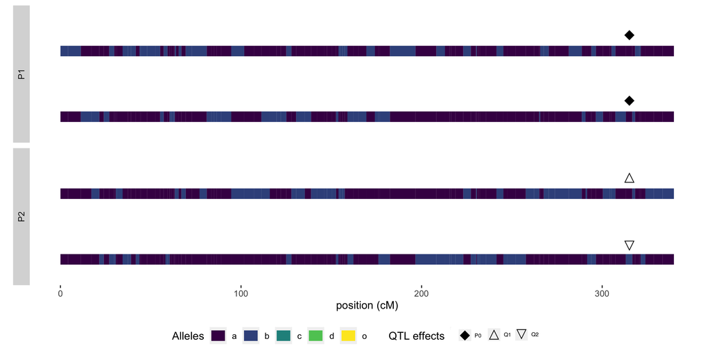

```r
plot_fullsib_phases(p)
```